# Prediction Markets

## Do forecasts improve near resolution?

These data describe 800 resolved Manifold Markets questions and 43,694 daily probability snapshots. The probability is the crowd’s forecast that the answer will be YES. Because Manifold uses play money, these results describe this platform and dataset rather than prediction markets in general. The Parquet files come from the [PPBDS r4ds-8 tutorial](https://github.com/PPBDS/misc.tutorials/tree/main/inst/tutorials/r4ds-8/data) and were built from Manifold Markets’ public API.

The absolute prediction error is the distance between a forecast and the outcome (coded as 1 for YES and 0 for NO). The time buckets compare forecasts made at different distances from resolution.

### Accuracy by time horizon

The table gives the mean absolute error and the number of daily forecasts in each time bucket. A smaller error means the forecasts were closer to the eventual outcome.

| Time until resolution | Mean absolute error | Daily forecasts |
| --- | --- | --- |
| 90+ days | 39.9% | 5239 |
| 30–90 days | 31.1% | 15588 |
| 7–30 days | 27.9% | 16467 |
| 1–7 days | 18.0% | 5600 |
| Final day | 9.0% | 800 |

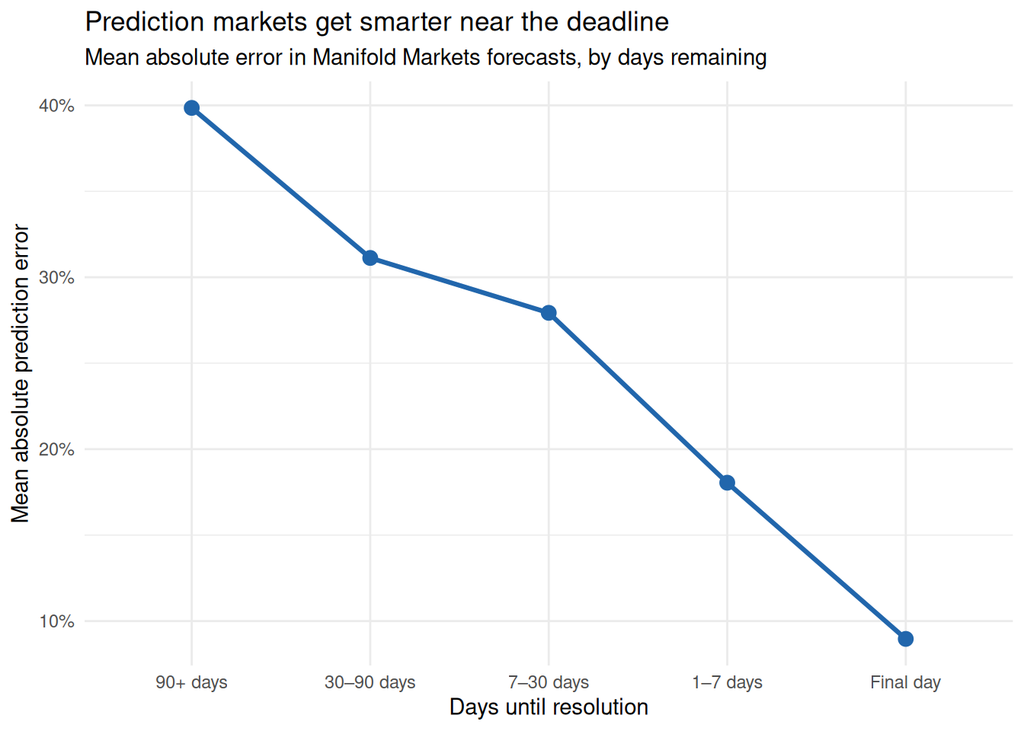

## How calibrated are final-day forecasts?

Calibration asks whether events assigned a given probability happen about that often. The next chart shows the distribution of forecasts made on each market’s resolution day.

[figure not shown]

For the calibration table, forecasts are grouped into ten-percentage-point bins. `Actual YES rate` is the share of markets in each bin that resolved YES; the count shows how many markets support that estimate.

| Forecast bin | Actual YES rate | Markets |
| --- | --- | --- |
| 0% | 0.5% | 373 |
| 10% | 3.0% | 67 |
| 20% | 24.0% | 25 |
| 30% | 5.6% | 18 |
| 40% | 30.0% | 20 |
| 50% | 66.7% | 21 |
| 60% | 50.0% | 20 |
| 70% | 92.3% | 13 |
| 80% | 90.9% | 11 |
| 90% | 100.0% | 30 |
| 100% | 99.5% | 202 |

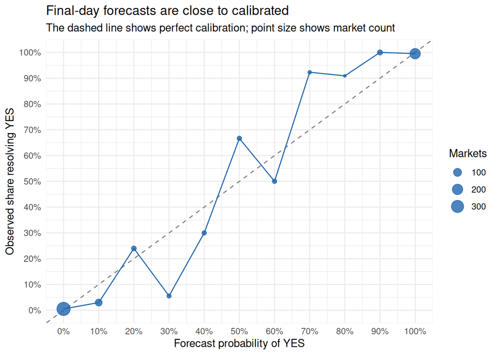